# ANDREW NG VIDEO TRANSLATION

I will try to modify an Andrew Ng video clip to match the audio of the same dialogue spoken by my Dad in "Indian English".

```python
import matplotlib.pyplot as plt
%matplotlib inline

import imageio
import numpy as np
import scipy.io.wavfile
import speechpy
import tqdm
```

# 1. Read input video

```python
reader = imageio.get_reader('Andrew_Ng.mp4')
video_fps = reader.get_meta_data()['fps']
```

```python
print(len(reader), "frames -", video_fps, "fps -", len(reader)//video_fps, "secs")
```

```
180 frames - 15.0 fps - 12.0 secs
```

# 2. Read audio files

```python
file_name = 'Andrew_Ng.wav'
fs, andrew_ng_audio = scipy.io.wavfile.read(file_name)
andrew_ng_audio = andrew_ng_audio[:,0]
```

```python
print(len(andrew_ng_audio), "samples - ", len(andrew_ng_audio)//fs, "secs")
```

```
529967 samples -  12 secs
```

```python
file_name = 'Nanna.wav'
fs, nanna_audio = scipy.io.wavfile.read(file_name)
nanna_audio = nanna_audio[:,0]
```

```python
print(len(nanna_audio), "samples - ", len(nanna_audio)//fs, "secs")
```

```
652288 samples -  14 secs
```

# 3. Extract MFCC features

```python
sampling_frequency = fs
frame_length = 0.025
frame_stride = 0.010
num_cepstral = 13
num_filters = 40
```

```python
andrew_ng_audio_mfcc = speechpy.feature.mfcc(andrew_ng_audio, sampling_frequency=sampling_frequency,
                                             frame_length=frame_length, frame_stride=frame_stride,
                                             num_cepstral=num_cepstral, num_filters=num_filters)
```

```python
nanna_audio_mfcc = speechpy.feature.mfcc(nanna_audio, sampling_frequency=fs,
                                         frame_length=frame_length, frame_stride=frame_stride,
                                         num_cepstral=num_cepstral, num_filters=num_filters)
```

```python
print(andrew_ng_audio_mfcc.shape, nanna_audio_mfcc.shape)
```

```
(1200, 13) (1477, 13)
```

```python
len(andrew_ng_audio)
```

```
529967
```

```python
(frame_stride*sampling_frequency)
```

```
441.0
```

```python
frame_length*sampling_frequency
```

```
1102.5
```

```python
print(441*1199 + 1102.5, 441*1200 + 1102.5, 441*1201 + 1102.5, 441*1202 + 1102.5)
```

```
529861.5 530302.5 530743.5 531184.5
```

```python
(len(andrew_ng_audio) - (frame_length*sampling_frequency))//(frame_stride*sampling_frequency) + 1
```

```
1200.0
```

```python
(len(nanna_audio) - (frame_length*sampling_frequency))//(frame_stride*sampling_frequency) + 1
```

```
1477.0
```

```python
1477*0.01*15
```

```
221.54999999999998
```

# 4. Compare MFCC features of the two audio files, and get a mapping

```python
def euc_dist(v1, v2):
    '''Euclidean distance between two (column) vectors v1 and v2'''
    return np.dot(v1.T, v2)
```

```python
dists = np.zeros((len(andrew_ng_audio_mfcc), len(nanna_audio_mfcc)))

for i in tqdm.tqdm(range(len(andrew_ng_audio_mfcc))):
    for j in range(len(nanna_audio_mfcc)):
        dists[i, j] = euc_dist(andrew_ng_audio_mfcc[i].T, nanna_audio_mfcc[j].T)
```

```
Text(0,0.5,'andrew_ng')
```

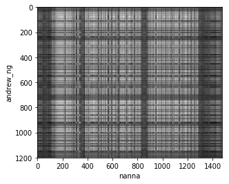

```python
plt.imshow(dists, cmap='gray', vmin=dists.min(), vmax=dists.max())
plt.xlabel("nanna")
plt.ylabel("andrew_ng")
```

## 4.2. Isolating the distances between all frames in source audio and only the 100 frames around that time in the target audio

```python
local_dists = dists.max()*np.ones((len(dists), 100))
for i in range(len(andrew_ng_audio_mfcc)):
    min_index = max(0, i-50)
    max_index = min(len(nanna_audio_mfcc)-1, i+50)
    local_dists_at_i = dists[i][min_index:max_index]
    if len(local_dists_at_i) < 100:
        if min_index == 0:
            local_dists[i][-len(local_dists_at_i):] = local_dists_at_i
        else:
            local_dists[i][:len(local_dists_at_i)] = local_dists_at_i
    else:
        local_dists[i] = local_dists_at_i
```

```
Text(0,0.5,'andrew_ng')
```

[figure not shown]

```python
plt.figure(figsize=(10, 10))
plt.imshow(local_dists, cmap='gray', vmin=local_dists.min(), vmax=local_dists.max())
plt.xlabel("nanna - relative")
plt.ylabel("andrew_ng")
```

## 4.3. Finding the indices of the frame numbers in the target audio that are least distant to each frame in the source audio, within 100 frames around that source audio frame

```python
local_time_maps = np.argmin(local_dists, axis=1)
```

```python
local_time_maps[:200]
```

```
array([50, 49, 48, 47, 46, 45, 44, 43, 42, 41, 40, 39, 38, 37, 36, 35, 34,
       33, 32, 31, 30, 29, 28, 27, 26, 25, 24, 23, 22, 21, 81, 73, 18, 78,
       77, 69, 75, 67, 73, 65, 64, 63, 62, 61, 60, 66, 65, 57, 63, 55, 61,
        2,  1,  0, 42, 49, 48, 54, 46, 45, 44, 43, 49, 48, 40, 46, 38, 37,
       36, 42, 34, 33, 32, 31, 30, 29, 28, 27, 26, 25, 24, 19, 22, 21, 20,
       19, 18, 17, 16, 15, 14, 13, 12, 11, 10,  9,  8,  7,  6,  5, 11,  3,
        2,  1,  0,  6, 39, 38, 42, 41, 40, 39, 38, 37, 46, 35, 34, 33, 32,
       31, 20, 19, 18, 17, 16, 15,  5, 13,  3, 11,  1,  9, 13,  7, 19, 18,
       17, 16, 15, 14, 13,  7, 11, 10,  9,  3,  7,  6,  5,  4,  3,  2,  1,
        0,  1,  1,  0,  5,  4,  3,  2,  1,  0,  0,  0,  5, 23, 26, 21, 25,
       99, 99, 99, 99, 99, 98, 99, 98, 97, 96,  9,  7, 11, 92, 91,  4,  2,
        1,  0,  0,  0, 84, 83, 82, 81, 80, 79, 78, 64, 63])
```

```python
global_time_maps = np.array([local_time_maps[i]-50+i for i in range(len(local_time_maps))])
```

```python
global_time_maps[-200:]
```

```
array([ 993,  993,  997,  997,  993,  997,  997,  999, 1026, 1026, 1026,
       1026, 1026, 1026, 1026, 1026, 1026, 1026, 1026, 1026, 1026, 1026,
       1026, 1026, 1026, 1068, 1068, 1071, 1026, 1026, 1026, 1026, 1026,
       1026, 1083, 1083, 1083, 1026, 1083, 1083, 1083, 1083, 1083, 1083,
       1026, 1083, 1083, 1083, 1083, 1083, 1083, 1083, 1083, 1083, 1083,
       1083, 1026, 1068, 1083, 1026, 1068, 1068, 1068, 1068, 1068, 1068,
       1068, 1068, 1045, 1083, 1083, 1083, 1083, 1083, 1083, 1083, 1083,
       1083, 1083, 1083, 1083, 1130, 1131, 1130, 1083, 1068, 1068, 1068,
       1068, 1136, 1136, 1136, 1141, 1136, 1136, 1068, 1068, 1141, 1136,
       1136, 1136, 1136, 1141, 1068, 1068, 1068, 1068, 1068, 1068, 1068,
       1068, 1136, 1136, 1136, 1136, 1136, 1136, 1136, 1136, 1137, 1136,
       1137, 1136, 1136, 1136, 1136, 1136, 1136, 1136, 1136, 1136, 1135,
       1135, 1135, 1136, 1136, 1136, 1136, 1136, 1136, 1135, 1135, 1136,
       1136, 1136, 1164, 1164, 1161, 1161, 1161, 1161, 1161, 1161, 1161,
       1161, 1161, 1204, 1204, 1204, 1204, 1204, 1164, 1164, 1164, 1204,
       1164, 1164, 1207, 1207, 1164, 1164, 1207, 1136, 1207, 1207, 1164,
       1164, 1164, 1207, 1207, 1207, 1164, 1207, 1164, 1204, 1204, 1204,
       1204, 1163, 1163, 1163, 1141, 1163, 1163, 1163, 1163, 1163, 1163,
       1163, 1232])
```

Checking if the numbers are in ascending order:

```python
np.sum([global_time_maps[i+1] < global_time_maps[i] for i in range(len(global_time_maps)-1)])
```

```
191
```

```
Text(0.5,1,'Audio frame numbers in target')
```

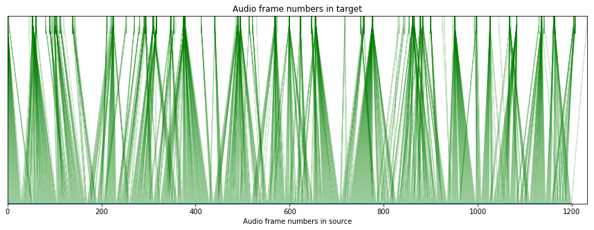

```python
mapping = global_time_maps
fig = plt.figure(figsize=(15, 5))
plt.plot(list(range(len(mapping))), [0]*len(mapping))
plt.ylim([0, 1.05])
plt.xlim([0, mapping.max()])
for i in range(len(mapping)):
    plt.gca().arrow(i, 0, mapping[i]-i, 1, head_width=0.1, head_length=0.1, fc='r', ec='g', alpha=0.2)
plt.gca().axes.get_yaxis().set_visible(False)
plt.xlabel("Audio frame numbers in source")
plt.title("Audio frame numbers in target")
```

## 4.4. Taking the median of those target audio frame numbers to smooth them

```python
def smooth_global_time_maps(global_time_maps, median_window):
    global_time_maps_smoothed = np.zeros((len(global_time_maps) - median_window))
    for i in range(len(global_time_maps) - median_window):
        global_time_maps_smoothed[i] = np.median(global_time_maps[i:i+median_window])
    global_time_maps_smoothed = np.concatenate(([global_time_maps_smoothed[0]]*(median_window//2),
                                                global_time_maps_smoothed,
                                                [global_time_maps_smoothed[-1]]*(median_window//2))).astype(int)
    return global_time_maps_smoothed
```

```python
def plot_time_maps(mapping, median_window):
    fig = plt.figure(figsize=(15, 5))
    plt.plot(list(range(len(mapping))), [0]*len(mapping), label="median_window = "+str(median_window))
    plt.legend()
    plt.ylim([0, 1.05])
    plt.xlim([0, mapping.max()])
    for i in range(len(mapping)):
        plt.gca().arrow(i, 0, mapping[i]-i, 1, head_width=0.1, head_length=0.1, fc='r', ec='g', alpha=0.2)
    plt.gca().axes.get_yaxis().set_visible(False)
    plt.xlabel("Audio frame numbers in source")
    plt.title("Audio frame numbers in target")
```

- ### median_window = 10

```python
median_window = 10
global_time_maps_smoothed_10 = smooth_global_time_maps(global_time_maps, median_window)
```

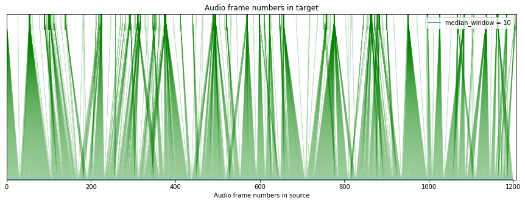

```python
plot_time_maps(global_time_maps_smoothed_10, median_window)
```

```python
global_time_maps_smoothed_10
```

```
array([   0,    0,    0, ..., 1163, 1163, 1163])
```

Checking if the numbers are all in ascending order:

```python
np.sum([global_time_maps_smoothed_10[i+1] < global_time_maps_smoothed_10[i] for i in range(len(global_time_maps_smoothed_10)-1)])
```

```
70
```

Seeing the number of unique target values:

```python
len(np.unique(global_time_maps_smoothed_10))
```

```
163
```

- ### median_window = 50

```python
median_window = 50
global_time_maps_smoothed_50 = smooth_global_time_maps(global_time_maps, median_window)
```

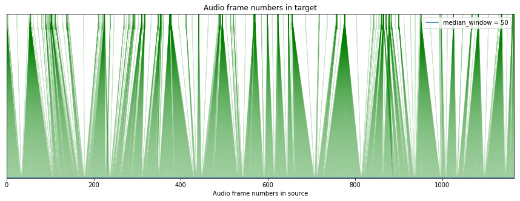

```python
plot_time_maps(global_time_maps_smoothed_50, median_window)
```

Checking if the numbers are all in ascending order:

```python
np.sum([global_time_maps_smoothed_50[i+1] < global_time_maps_smoothed_50[i] for i in range(len(global_time_maps_smoothed_50)-1)])
```

```
6
```

Seeing the number of unique target values:

```python
len(np.unique(global_time_maps_smoothed_50))
```

```
161
```

- ### median_window = 100

```python
median_window = 100
global_time_maps_smoothed_100 = smooth_global_time_maps(global_time_maps, median_window)
```

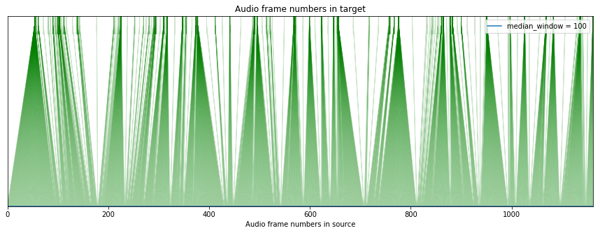

```python
plot_time_maps(global_time_maps_smoothed_100, median_window)
```

Checking if the numbers are all in ascending order:

```python
np.sum([global_time_maps_smoothed_100[i+1] < global_time_maps_smoothed_100[i] for i in range(len(global_time_maps_smoothed_100)-1)])
```

```
0
```

```python
len(np.unique(global_time_maps_smoothed_100))
```

```
168
```

- ### Choose

Hence, let us choose global_time_maps_smoothed_100 (median_window = 100), since it has no criss-cross mappings.

```python
global_time_maps_smoothed = global_time_maps_smoothed_100
```

## 4.5. Get mapping of frames in video

Get all mapped video_frame_numbers from all mapped audio_frame_numbers:

```python
target_video_frame_numbers = np.round(global_time_maps_smoothed * frame_stride * video_fps).astype(int)
```

```python
target_video_frame_numbers
```

```
array([  8,   8,   8, ..., 174, 174, 174])
```

Get the key_frames_in_target_video as the unique set of all mapped target_video_frame_numbers:

```python
key_frames_in_target_video = np.unique(target_video_frame_numbers)
```

```python
key_frames_in_target_video
```

```
array([  8,   9,  11,  12,  13,  14,  15,  16,  17,  18,  19,  21,  27,
        32,  33,  34,  36,  38,  39,  40,  41,  42,  43,  44,  45,  46,
        47,  48,  50,  52,  53,  55,  56,  57,  59,  62,  64,  66,  69,
        73,  74,  76,  77,  78,  79,  82,  85,  86,  88,  90,  92,  93,
        94,  95,  97,  98, 103, 108, 110, 113, 114, 115, 116, 120, 125,
       126, 127, 128, 129, 130, 131, 132, 134, 135, 137, 139, 141, 142,
       143, 146, 149, 150, 152, 154, 155, 158, 160, 162, 166, 170, 171,
       173, 174])
```

Get the corresponding key_frames_in_source_video:

First, extract all those frames in source video that correspond to each key frame in target video:

```python
key_frames_in_source_video_dict = { target_key_frame : np.where(target_video_frame_numbers == target_key_frame) for target_key_frame in key_frames_in_target_video }
```

```python
key_frames_in_source_video_dict
```

```
{8: (array([ 0,  1,  2,  3,  4,  5,  6,  7,  8,  9, 10, 11, 12, 13, 14, 15, 16,
         17, 18, 19, 20, 21, 22, 23, 24, 25, 26, 27, 28, 29, 30, 31, 32, 33,
         34, 35, 36, 37, 38, 39, 40, 41, 42, 43, 44, 45, 46, 47, 48, 49, 50,
         51, 52, 53, 54, 55, 56, 57, 58, 59, 60, 61, 62, 63, 64, 65, 66, 67,
         68, 69, 70, 71, 72, 73, 74, 75, 76, 77, 78, 79, 80, 81, 82, 83, 84,
         85, 86, 87, 88, 89, 90, 91, 92, 93, 94]),),
 9: (array([ 95,  96,  97,  98,  99, 100, 101, 102, 103, 104, 105]),),
 11: (array([106]),),
 12: (array([107, 108]),),
 13: (array([109]),),
 14: (array([110, 111, 112, 113, 114, 115, 116, 117, 118, 119, 120, 121, 122]),),
 15: (array([123, 124, 125, 126, 127, 128, 129, 130, 131, 132, 133, 134, 135,
         136, 137, 138, 139, 140, 141, 142, 143, 144, 145, 146, 147, 148,
         149, 150, 151, 152]),),
 16: (array([153, 154, 155, 156]),),
```

[output cut: 142 more lines]

Then, take the median of all source video frames corresponding to each key_frame_in_target_video, to get the corresponding key_frame_in_source_video:

```python
key_frames_in_source_video = np.round([ np.median(key_frames_in_source_video_dict[key_frame_in_target_video])*frame_stride*video_fps for key_frame_in_target_video in key_frames_in_source_video_dict ]).astype(int)
```

```python
key_frames_in_source_video
```

```
array([  7,  15,  16,  16,  16,  17,  21,  23,  24,  25,  25,  26,  27,
        27,  28,  32,  35,  35,  36,  36,  36,  37,  37,  39,  40,  42,
        43,  46,  48,  50,  52,  52,  54,  60,  64,  65,  65,  66,  67,
        68,  74,  79,  80,  81,  81,  81,  82,  86,  88,  91,  93,  95,
        96,  96,  97, 102, 106, 106, 107, 107, 108, 110, 116, 122, 122,
       122, 123, 123, 125, 129, 132, 135, 139, 140, 140, 140, 141, 141,
       145, 149, 149, 150, 151, 153, 155, 155, 157, 162, 164, 168, 172,
       172, 176])
```

# 5. Get new frame numbers in target video

```python
key_frames_in_source_video
```

```
array([  7,  15,  16,  16,  16,  17,  21,  23,  24,  25,  25,  26,  27,
        27,  28,  32,  35,  35,  36,  36,  36,  37,  37,  39,  40,  42,
        43,  46,  48,  50,  52,  52,  54,  60,  64,  65,  65,  66,  67,
        68,  74,  79,  80,  81,  81,  81,  82,  86,  88,  91,  93,  95,
        96,  96,  97, 102, 106, 106, 107, 107, 108, 110, 116, 122, 122,
       122, 123, 123, 125, 129, 132, 135, 139, 140, 140, 140, 141, 141,
       145, 149, 149, 150, 151, 153, 155, 155, 157, 162, 164, 168, 172,
       172, 176])
```

```python
key_frames_in_target_video
```

```
array([  8,   9,  11,  12,  13,  14,  15,  16,  17,  18,  19,  21,  27,
        32,  33,  34,  36,  38,  39,  40,  41,  42,  43,  44,  45,  46,
        47,  48,  50,  52,  53,  55,  56,  57,  59,  62,  64,  66,  69,
        73,  74,  76,  77,  78,  79,  82,  85,  86,  88,  90,  92,  93,
        94,  95,  97,  98, 103, 108, 110, 113, 114, 115, 116, 120, 125,
       126, 127, 128, 129, 130, 131, 132, 134, 135, 137, 139, 141, 142,
       143, 146, 149, 150, 152, 154, 155, 158, 160, 162, 166, 170, 171,
       173, 174])
```

```python
total_number_of_target_frames = int(np.round(len(nanna_audio)/fs*video_fps))
target_video_has_source_frame_numbers = np.zeros(total_number_of_target_frames)
```

```python
key_frames_in_source_video = np.concatenate(([0], key_frames_in_source_video, [len(reader) - 1]))
key_frames_in_target_video = np.concatenate(([0], key_frames_in_target_video, [total_number_of_target_frames - 1]))
```

```python
key_frames_in_source_video
```

```
array([  0,   7,  15,  16,  16,  16,  17,  21,  23,  24,  25,  25,  26,
        27,  27,  28,  32,  35,  35,  36,  36,  36,  37,  37,  39,  40,
        42,  43,  46,  48,  50,  52,  52,  54,  60,  64,  65,  65,  66,
        67,  68,  74,  79,  80,  81,  81,  81,  82,  86,  88,  91,  93,
        95,  96,  96,  97, 102, 106, 106, 107, 107, 108, 110, 116, 122,
       122, 122, 123, 123, 125, 129, 132, 135, 139, 140, 140, 140, 141,
       141, 145, 149, 149, 150, 151, 153, 155, 155, 157, 162, 164, 168,
       172, 172, 176, 179])
```

```python
key_frames_in_target_video
```

```
array([  0,   8,   9,  11,  12,  13,  14,  15,  16,  17,  18,  19,  21,
        27,  32,  33,  34,  36,  38,  39,  40,  41,  42,  43,  44,  45,
        46,  47,  48,  50,  52,  53,  55,  56,  57,  59,  62,  64,  66,
        69,  73,  74,  76,  77,  78,  79,  82,  85,  86,  88,  90,  92,
        93,  94,  95,  97,  98, 103, 108, 110, 113, 114, 115, 116, 120,
       125, 126, 127, 128, 129, 130, 131, 132, 134, 135, 137, 139, 141,
       142, 143, 146, 149, 150, 152, 154, 155, 158, 160, 162, 166, 170,
       171, 173, 174, 221])
```

```python
for k in range(1, len(key_frames_in_source_video)):
    from_source_video_frame = key_frames_in_source_video[k-1]
    to_source_video_frame = key_frames_in_source_video[k]
    from_target_video_frame = key_frames_in_target_video[k-1]
    to_target_video_frame = key_frames_in_target_video[k]
    number_of_target_frames = to_target_video_frame - from_target_video_frame
    if from_source_video_frame != to_source_video_frame:
        new_source_video_frames_to_place_in_target_video = np.arange(from_source_video_frame,
                                                                     to_source_video_frame,
                                                                     (to_source_video_frame - from_source_video_frame)/number_of_target_frames)
        target_video_has_source_frame_numbers[from_target_video_frame:to_target_video_frame] = new_source_video_frames_to_place_in_target_video[:number_of_target_frames]
    else:
        target_video_has_source_frame_numbers[from_target_video_frame:to_target_video_frame] = np.array([to_source_video_frame]*number_of_target_frames)

target_video_has_source_frame_numbers[-1] = key_frames_in_source_video[-1]
```

```python
target_video_has_source_frame_numbers
```

```
array([  0.        ,   0.875     ,   1.75      ,   2.625     ,
         3.5       ,   4.375     ,   5.25      ,   6.125     ,
         7.        ,  15.        ,  15.5       ,  16.        ,
        16.        ,  16.        ,  17.        ,  21.        ,
        23.        ,  24.        ,  25.        ,  25.        ,
        25.5       ,  26.        ,  26.16666667,  26.33333333,
        26.5       ,  26.66666667,  26.83333333,  27.        ,
        27.        ,  27.        ,  27.        ,  27.        ,
        27.        ,  28.        ,  32.        ,  33.5       ,
        35.        ,  35.        ,  35.        ,  36.        ,
        36.        ,  36.        ,  37.        ,  37.        ,
        39.        ,  40.        ,  42.        ,  43.        ,
        46.        ,  47.        ,  48.        ,  49.        ,
        50.        ,  52.        ,  52.        ,  52.        ,
        54.        ,  60.        ,  62.        ,  64.        ,
        64.33333333,  64.66666667,  65.        ,  65.        ,
        65.        ,  65.5       ,  66.        ,  66.33333333,
        66.66666667,  67.        ,  67.25      ,  67.5       ,
        67.75      ,  68.        ,  74.        ,  76.5       ,
        79.        ,  80.        ,  81.        ,  81.        ,
        81.        ,  81.        ,  81.        ,  81.33333333,
        81.66666667,  82.        ,  86.        ,  87.        ,
        88.        ,  89.5       ,  91.        ,  92.        ,
        93.        ,  95.        ,  96.        ,  96.        ,
        96.5       ,  97.        , 102.        , 102.8       ,
       103.6       , 104.4       , 105.2       , 106.        ,
       106.        , 106.        , 106.        , 106.        ,
       106.        , 106.5       , 107.        , 107.        ,
       107.        , 107.        , 108.        , 110.        ,
       116.        , 117.5       , 119.        , 120.5       ,
       122.        , 122.        , 122.        , 122.        ,
       122.        , 122.        , 122.        , 123.        ,
       123.        , 125.        , 129.        , 132.        ,
       135.        , 137.        , 139.        , 140.        ,
       140.        , 140.        , 140.        , 140.        ,
       140.5       , 141.        , 141.        , 145.        ,
       146.33333333, 147.66666667, 149.        , 149.        ,
       149.        , 149.        , 150.        , 150.5       ,
       151.        , 152.        , 153.        , 155.        ,
       155.        , 155.        , 155.        , 156.        ,
       157.        , 159.5       , 162.        , 162.5       ,
       163.        , 163.5       , 164.        , 165.        ,
       166.        , 167.        , 168.        , 172.        ,
       172.        , 172.        , 176.        , 176.06382979,
       176.12765957, 176.19148936, 176.25531915, 176.31914894,
       176.38297872, 176.44680851, 176.5106383 , 176.57446809,
       176.63829787, 176.70212766, 176.76595745, 176.82978723,
       176.89361702, 176.95744681, 177.0212766 , 177.08510638,
       177.14893617, 177.21276596, 177.27659574, 177.34042553,
       177.40425532, 177.46808511, 177.53191489, 177.59574468,
       177.65957447, 177.72340426, 177.78723404, 177.85106383,
       177.91489362, 177.9787234 , 178.04255319, 178.10638298,
       178.17021277, 178.23404255, 178.29787234, 178.36170213,
       178.42553191, 178.4893617 , 178.55319149, 178.61702128,
       178.68085106, 178.74468085, 178.80851064, 178.87234043,
       178.93617021, 179.        ])
```

# 6. Make new frames

```python
frames_orig = []
for frame in reader:
    frames_orig.append(frame)
```

```python
len(frames)
```

```
180
```

```python
new_frames = []
for frame_orig, source_frame_number in zip(frames_orig, target_video_has_source_frame_numbers):
    if np.ceil(source_frame_number) != source_frame_number:
        new_frame = np.array(frames_orig[int(np.ceil(source_frame_number))]*(source_frame_number - np.floor(source_frame_number)) + frames_orig[int(np.floor(source_frame_number))]*(np.ceil(source_frame_number) - source_frame_number)).astype('uint8')
    else:
        new_frame = frames_orig[int(source_frame_number)]
    new_frames.append(new_frame)
```

```python
imageio.mimwrite('/tmp/video.mp4', new_frames , fps=15)
```

[output not shown]

```python
import subprocess
command = ['ffmpeg', '-loglevel', 'error',
           '-i', '/tmp/video.mp4', '-i', 'Nanna.mp3',
           '-vcodec', 'libx264', '-preset', 'ultrafast', '-profile:v', 'main', '-acodec', 'aac', '-strict', '-2',
           'new_Andrew_Ng.mp4']
subprocess.call(command)
```

```
0
```